# EC1 – Applied Data Science

### Dataset Schema & Access Method

- **Source:** UCI ML Repository + Kaggle mirror
- **Rows × Columns:** 506 × 14
- **Format:** Space‑separated, no header (manually added using UCI schema)
- **Access:** Loaded locally using `pandas.read_csv()` with regex delimiter.

Below is a 10‑row preview to validate schema and types.

```python
df = pd.read_csv("housing.csv", sep=r"\s+", header=None)
df.head(10)
```

|  | 0 | 1 | 2 | 3 | 4 | 5 | 6 | 7 | 8 | 9 | 10 | 11 | 12 | 13 |
| --- | --- | --- | --- | --- | --- | --- | --- | --- | --- | --- | --- | --- | --- | --- |
| 0 | 0.00632 | 18.0 | 2.31 | 0 | 0.538 | 6.575 | 65.2 | 4.0900 | 1 | 296.0 | 15.3 | 396.90 | 4.98 | 24.0 |
| 1 | 0.02731 | 0.0 | 7.07 | 0 | 0.469 | 6.421 | 78.9 | 4.9671 | 2 | 242.0 | 17.8 | 396.90 | 9.14 | 21.6 |
| 2 | 0.02729 | 0.0 | 7.07 | 0 | 0.469 | 7.185 | 61.1 | 4.9671 | 2 | 242.0 | 17.8 | 392.83 | 4.03 | 34.7 |
| 3 | 0.03237 | 0.0 | 2.18 | 0 | 0.458 | 6.998 | 45.8 | 6.0622 | 3 | 222.0 | 18.7 | 394.63 | 2.94 | 33.4 |
| 4 | 0.06905 | 0.0 | 2.18 | 0 | 0.458 | 7.147 | 54.2 | 6.0622 | 3 | 222.0 | 18.7 | 396.90 | 5.33 | 36.2 |
| 5 | 0.02985 | 0.0 | 2.18 | 0 | 0.458 | 6.430 | 58.7 | 6.0622 | 3 | 222.0 | 18.7 | 394.12 | 5.21 | 28.7 |
| 6 | 0.08829 | 12.5 | 7.87 | 0 | 0.524 | 6.012 | 66.6 | 5.5605 | 5 | 311.0 | 15.2 | 395.60 | 12.43 | 22.9 |
| 7 | 0.14455 | 12.5 | 7.87 | 0 | 0.524 | 6.172 | 96.1 | 5.9505 | 5 | 311.0 | 15.2 | 396.90 | 19.15 | 27.1 |
| 8 | 0.21124 | 12.5 | 7.87 | 0 | 0.524 | 5.631 | 100.0 | 6.0821 | 5 | 311.0 | 15.2 | 386.63 | 29.93 | 16.5 |
| 9 | 0.17004 | 12.5 | 7.87 | 0 | 0.524 | 6.004 | 85.9 | 6.5921 | 5 | 311.0 | 15.2 | 386.71 | 17.10 | 18.9 |

### Dataset Overview

```python
from IPython.display import Markdown, display

# Static text (edit if needed)
DATASET_NAME = "Boston Housing Dataset"
SOURCE = "UCI Machine Learning Repository (via Kaggle)"
TARGET = "MEDV (Median House Price)"
ANALYSIS_TYPE = "Exploratory Data Analysis (EDA)"

# Dynamic values from df
n_rows = len(df)
n_cols = df.shape[1]

# Single combined Markdown table
table_md = f"""
### Dataset Overview

| Attribute         | Details                                         |
|------------------|--------------------------------------------------|
| Dataset Name      | {DATASET_NAME}                                   |
| Source            | {SOURCE}                                         |
| Number of Rows    | {n_rows}                                         |
| Number of Columns | {n_cols}                                         |
| Target Variable   | {TARGET}                                         |
| Analysis Type     | {ANALYSIS_TYPE}                                  |
"""

display(Markdown(table_md))
```

Dataset Overview

| Attribute | Details |
| --- | --- |
| Dataset Name | Boston Housing Dataset |
| Source | UCI Machine Learning Repository (via Kaggle) |
| Number of Rows | 506 |
| Number of Columns | 14 |
| Target Variable | MEDV (Median House Price) |
| Analysis Type | Exploratory Data Analysis (EDA) |

### 5.3: Data Understanding & Missing Value Check

We examine dataset structure, assign column names, and verify missing values.

```python
df.columns = ["CRIM","ZN","INDUS","CHAS","NOX","RM","AGE","DIS","RAD",
"TAX","PTRATIO","B","LSTAT","MEDV"]
df.head()
```

|  | CRIM | ZN | INDUS | CHAS | NOX | RM | AGE | DIS | RAD | TAX | PTRATIO | B | LSTAT | MEDV |
| --- | --- | --- | --- | --- | --- | --- | --- | --- | --- | --- | --- | --- | --- | --- |
| 0 | 0.00632 | 18.0 | 2.31 | 0 | 0.538 | 6.575 | 65.2 | 4.0900 | 1 | 296.0 | 15.3 | 396.90 | 4.98 | 24.0 |
| 1 | 0.02731 | 0.0 | 7.07 | 0 | 0.469 | 6.421 | 78.9 | 4.9671 | 2 | 242.0 | 17.8 | 396.90 | 9.14 | 21.6 |
| 2 | 0.02729 | 0.0 | 7.07 | 0 | 0.469 | 7.185 | 61.1 | 4.9671 | 2 | 242.0 | 17.8 | 392.83 | 4.03 | 34.7 |
| 3 | 0.03237 | 0.0 | 2.18 | 0 | 0.458 | 6.998 | 45.8 | 6.0622 | 3 | 222.0 | 18.7 | 394.63 | 2.94 | 33.4 |
| 4 | 0.06905 | 0.0 | 2.18 | 0 | 0.458 | 7.147 | 54.2 | 6.0622 | 3 | 222.0 | 18.7 | 396.90 | 5.33 | 36.2 |

```python
import os
os.getcwd()
```

```
'C:\\MBA-in-AI-for-Business\\SECOND SEMESTER 2024-25\\Applied Data Science (S1-25_MBACCZG581)\\EC1\\Assignment 1\\Phase 1'
```

```python
df.isna().sum()
```

```
CRIM       0
ZN         0
INDUS      0
CHAS       0
NOX        0
RM         0
AGE        0
DIS        0
RAD        0
TAX        0
PTRATIO    0
B          0
LSTAT      0
MEDV       0
dtype: int64
```

```python
import pandas as pd
import seaborn as sns
import matplotlib.pyplot as plt
```

```python
df = pd.read_csv("housing.csv", sep=r"\s+", header=None)
```

```python
column_names = [    "CRIM","ZN","INDUS","CHAS","NOX","RM","AGE","DIS",
    "RAD","TAX","PTRATIO","B","LSTAT","MEDV"]

df = pd.read_csv("housing.csv", sep=r"\s+", header=None)
df.columns = column_names
df.head()
```

|  | CRIM | ZN | INDUS | CHAS | NOX | RM | AGE | DIS | RAD | TAX | PTRATIO | B | LSTAT | MEDV |
| --- | --- | --- | --- | --- | --- | --- | --- | --- | --- | --- | --- | --- | --- | --- |
| 0 | 0.00632 | 18.0 | 2.31 | 0 | 0.538 | 6.575 | 65.2 | 4.0900 | 1 | 296.0 | 15.3 | 396.90 | 4.98 | 24.0 |
| 1 | 0.02731 | 0.0 | 7.07 | 0 | 0.469 | 6.421 | 78.9 | 4.9671 | 2 | 242.0 | 17.8 | 396.90 | 9.14 | 21.6 |
| 2 | 0.02729 | 0.0 | 7.07 | 0 | 0.469 | 7.185 | 61.1 | 4.9671 | 2 | 242.0 | 17.8 | 392.83 | 4.03 | 34.7 |
| 3 | 0.03237 | 0.0 | 2.18 | 0 | 0.458 | 6.998 | 45.8 | 6.0622 | 3 | 222.0 | 18.7 | 394.63 | 2.94 | 33.4 |
| 4 | 0.06905 | 0.0 | 2.18 | 0 | 0.458 | 7.147 | 54.2 | 6.0622 | 3 | 222.0 | 18.7 | 396.90 | 5.33 | 36.2 |

```python
len(df.columns)
```

```
14
```

```python
df.dtypes
df["CHAS"] = df["CHAS"].astype("category") # optional but recommended
df.dtypes
```

```
CRIM        float64
ZN          float64
INDUS       float64
CHAS       category
NOX         float64
RM          float64
AGE         float64
DIS         float64
RAD           int64
TAX         float64
PTRATIO     float64
B           float64
LSTAT       float64
MEDV        float64
dtype: object
```

## Step 6: Data Transformation & Descriptive Statistics

### 6.1 Descriptive Statistics

Summary statistics are generated to understand data distribution and detect anomalies

```python
df.describe()
```

|  | CRIM | ZN | INDUS | NOX | RM | AGE | DIS | RAD | TAX | PTRATIO | B | LSTAT | MEDV |
| --- | --- | --- | --- | --- | --- | --- | --- | --- | --- | --- | --- | --- | --- |
| count | 506.000000 | 506.000000 | 506.000000 | 506.000000 | 506.000000 | 506.000000 | 506.000000 | 506.000000 | 506.000000 | 506.000000 | 506.000000 | 506.000000 | 506.000000 |
| mean | 3.613524 | 11.363636 | 11.136779 | 0.554695 | 6.284634 | 68.574901 | 3.795043 | 9.549407 | 408.237154 | 18.455534 | 356.674032 | 12.653063 | 22.532806 |
| std | 8.601545 | 23.322453 | 6.860353 | 0.115878 | 0.702617 | 28.148861 | 2.105710 | 8.707259 | 168.537116 | 2.164946 | 91.294864 | 7.141062 | 9.197104 |
| min | 0.006320 | 0.000000 | 0.460000 | 0.385000 | 3.561000 | 2.900000 | 1.129600 | 1.000000 | 187.000000 | 12.600000 | 0.320000 | 1.730000 | 5.000000 |
| 25% | 0.082045 | 0.000000 | 5.190000 | 0.449000 | 5.885500 | 45.025000 | 2.100175 | 4.000000 | 279.000000 | 17.400000 | 375.377500 | 6.950000 | 17.025000 |
| 50% | 0.256510 | 0.000000 | 9.690000 | 0.538000 | 6.208500 | 77.500000 | 3.207450 | 5.000000 | 330.000000 | 19.050000 | 391.440000 | 11.360000 | 21.200000 |
| 75% | 3.677083 | 12.500000 | 18.100000 | 0.624000 | 6.623500 | 94.075000 | 5.188425 | 24.000000 | 666.000000 | 20.200000 | 396.225000 | 16.955000 | 25.000000 |
| max | 88.976200 | 100.000000 | 27.740000 | 0.871000 | 8.780000 | 100.000000 | 12.126500 | 24.000000 | 711.000000 | 22.000000 | 396.900000 | 37.970000 | 50.000000 |

#### Interpretation of Descriptive Statistics

• **CRIM** shows very high variability (std 8.60), indicating large differences in crime rates across neighborhoods.

• **RM** (average rooms) has a mean of 6.28 and ranges from 3.56 to 8.78; this suggests moderate‑sized homes with some premium larger homes.

• **AGE** indicates older housing stock, with a median of 77%, meaning many homes were built before 1940.

• **DIS** range shows strong variation in distance to employment centers.

• **LSTAT** (lower‑income population %) varies widely; this is expected to strongly influence price.

• **MEDV** (price) ranges from 5 to 50, but values at 50 are capped due to dataset limitations. Overall, the descriptive statistics confirm that Boston neighborhoods differ widely in socio‑economic and structural characteristics, making this dataset suitable for exploratory analysis.

### 6.2 Outlier Detection Using Boxplots

Boxplots help identify extreme values that may distort analysis.

Boxplot Visualization to Detect Outliers In this step, we plot boxplots for all numeric columns to visually detect outliers (very high or very low unusual values). Outliers can distort analysis and must be handled in Phase 2. This chart helps identify which columns need cleaning.

### Outlier Treatment Using IQR Method

We apply the IQR method to cap extreme values while preserving all rows for analysis.

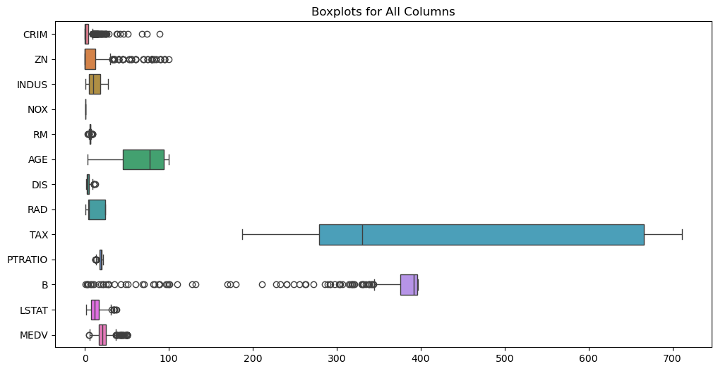

```python
plt.figure(figsize=(12,6))
sns.boxplot(data=df, orient="h")
plt.title("Boxplots for All Columns")
plt.show()
```

### Interpretation of Boxplot Results

These findings tell us which columns need outlier treatment in the next step using the IQR rule.